# Introdução

Os métodos e estudos de morfologia matemática inicialmente desenvolvidos para imagens binárias apresentam caracaterísticas imporatantes em aplicação em imagens tons de cinza. A operação dos métodos é mantida, porém neste caso as aplicações visam reduzir, ruídos, ressaltar bordas, destacare componentes, além de outros resultados.

Entretanto há um destaque para o método do gradiente morfológico, que utiliza a combinação entre erosão e dilatação para promover ressalto das bordas de uma imagem, da seguinte forma: $$ g = (f\oplus b) - (f \ominus b) $$

# Discussões sobre os métodos

A operação do gradiente mofológico funciona como uma filtragem passa-alta no dominio do tempo, ressaltando bordas e removendo regiões homogêneas. O operador de erosão funciona diminuindo as regiões com tons brancos, enquanto ao mesmo tempo a dilatação aumenta as regiões brancas, a subtração desses efeitos resultado nas bordas da imagem, como a seguir:

```python
import cv2
import numpy as np
import matplotlib.pyplot as plt
import pywt
```

- Abrir imagem:

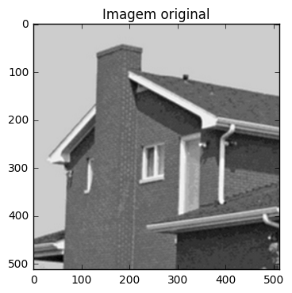

```python
img = np.array(cv2.imread('house.tif'))

plt.figure(1)
plt.imshow(img)
#plt.axis("off")
plt.title("Imagem original")
plt.show()
```

### Gradiente Morfológico:

- Elementro Estruturante 01:

```python
sizeEE = (5,5)

kernel = cv2.getStructuringElement(0, sizeEE, (-1,-1))
print(kernel)
```

```
[[1 1 1 1 1]
 [1 1 1 1 1]
 [1 1 1 1 1]
 [1 1 1 1 1]
 [1 1 1 1 1]]
```

```python
img_gradient = cv2.morphologyEx(img, cv2.MORPH_GRADIENT, kernel)
```

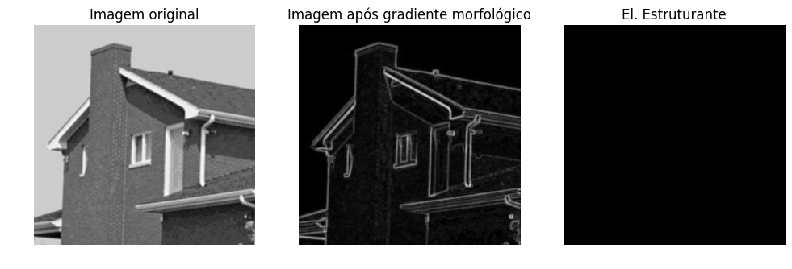

```python
plt.figure(2,figsize=(12,12))
plt.subplot(131)
plt.imshow(img)
plt.axis("off")
plt.title("Imagem original")

plt.subplot(132)
plt.imshow(img_gradient)
plt.axis("off")
plt.title("Imagem após gradiente morfológico")

plt.subplot(133)
plt.imshow(kernel, 'gray', interpolation='nearest')
plt.axis("off")
plt.grid()
plt.title("El. Estruturante")
plt.show()
```

- Elementro Estruturante 02:

```python
sizeEE = (5,5)

kernel = cv2.getStructuringElement(1, sizeEE, (-1,-1))
print(kernel)
```

```
[[0 0 1 0 0]
 [0 0 1 0 0]
 [1 1 1 1 1]
 [0 0 1 0 0]
 [0 0 1 0 0]]
```

```python
img_gradient = cv2.morphologyEx(img, cv2.MORPH_GRADIENT, kernel)
```

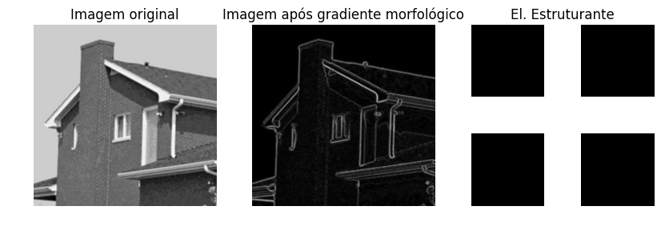

```python
plt.figure(3,figsize=(10,9))
plt.subplot(131)
plt.imshow(img)
plt.axis("off")
plt.title("Imagem original")

plt.subplot(132)
plt.imshow(img_gradient)
plt.axis("off")
plt.title("Imagem após gradiente morfológico")

plt.subplot(133)
plt.imshow(kernel, 'gray', interpolation='nearest')
plt.axis("off")
plt.grid()
plt.title("El. Estruturante")
plt.show()
```

- Elementro Estruturante 03:

```python
sizeEE = (5,5)

kernel = cv2.getStructuringElement(2, sizeEE, (-1,-1))
print(kernel)
```

```
[[0 0 1 0 0]
 [1 1 1 1 1]
 [1 1 1 1 1]
 [1 1 1 1 1]
 [0 0 1 0 0]]
```

```python
img_gradient = cv2.morphologyEx(img, cv2.MORPH_GRADIENT, kernel)
```

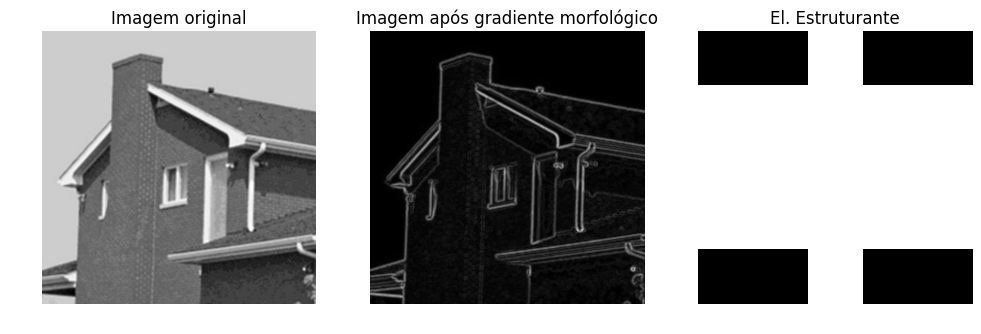

```python
plt.figure(3+1, figsize=(12,12))
plt.subplot(131)
plt.imshow(img)
plt.axis("off")
plt.title("Imagem original")

plt.subplot(132)
plt.imshow(img_gradient)
plt.axis("off")
plt.title("Imagem após gradiente morfológico")

plt.subplot(133)
plt.imshow(kernel, 'gray', interpolation='nearest')
plt.axis("off")
plt.grid()
plt.title("El. Estruturante")
plt.show()
```

Os diferentes tipos de elementos estruturante promovem ressalto das bordas nas regiões de crescimento ou retração do elemento.

# Conclusões

A utilização do gradiente morfológico para destacar bordas é equivalente a filtragem passa-alta no domínio espacial ou da frequência. A vatangem para tal método está no custo computacional menor que para implementação de tais filtros.